```python
# Submission by Rajagopal (Raj) Ramanujam
# Thera Bank Personal Loan Campaign
```

Dataset: * ID: Customer ID * Age: Customer's age in completed years * Experience: #years of professional experience * Income: Annual income of the customer ($000) * ZIP Code: Home Address ZIP code. * Family: Family size of the customer * CCAvg: Avg. spending on credit cards per month ($000) * Education: Education Level. 1: Undergrad; 2: Graduate; 3: Advanced/Professional * Mortgage: Value of house mortgage if any. ($000) * Personal Loan: Did this customer accept the personal loan offered in the last campaign? * Securities Account: Does the customer have a securities account with the bank? * CD Account: Does the customer have a certificate of deposit (CD) account with the bank? * Online: Does the customer use internet banking facilities? * Credit card: Does the customer use a credit card issued by the bank?

# Question#1 - Import the datasets and libraries, check datatype, statistical summary, shape, null values or incorrect imputation. (5 marks)

```python
import warnings
warnings.filterwarnings('ignore')
```

```python
import pandas as pd
from sklearn.linear_model import LogisticRegression

# importing ploting libraries
import matplotlib.pyplot as plt
# To enable plotting graphs in Jupyter notebook
%matplotlib inline

#importing seaborn for statistical plots
import seaborn as sns

#Let us break the X and y dataframes into training set and test set. For this we will use
#Sklearn package's data splitting function which is based on random function

from sklearn.model_selection import train_test_split

import numpy as np
import os,sys
from scipy import stats

# calculate accuracy measures and confusion matrix
from sklearn import metrics
```

```python
# Adjust pandas display and formatting settings

# Remove scientific notations and display numbers with 2 decimal points instead
pd.options.display.float_format = '{:,.2f}'.format

# Increase cell width
from IPython.core.display import display, HTML
display(HTML("<style>.container { width:98% !important; }</style>"))

# Update default style and size of charts
plt.style.use('ggplot')
plt.rcParams['figure.figsize'] = [10, 8]

# Increase max number of rows and columns to display in pandas tables
pd.set_option('display.max_columns', 500)
pd.set_option('display.max_rows', 500)
```

```python
pdata = pd.read_csv("Bank_Personal_Loan_Modelling.csv")
```

```python
pdata.head()
```

|  | ID | Age | Experience | Income | ZIP Code | Family | CCAvg | Education | Mortgage | Personal Loan | Securities Account | CD Account | Online | CreditCard |
| --- | --- | --- | --- | --- | --- | --- | --- | --- | --- | --- | --- | --- | --- | --- |
| 0 | 1 | 25 | 1 | 49 | 91107 | 4 | 1.60 | 1 | 0 | 0 | 1 | 0 | 0 | 0 |
| 1 | 2 | 45 | 19 | 34 | 90089 | 3 | 1.50 | 1 | 0 | 0 | 1 | 0 | 0 | 0 |
| 2 | 3 | 39 | 15 | 11 | 94720 | 1 | 1.00 | 1 | 0 | 0 | 0 | 0 | 0 | 0 |
| 3 | 4 | 35 | 9 | 100 | 94112 | 1 | 2.70 | 2 | 0 | 0 | 0 | 0 | 0 | 0 |
| 4 | 5 | 35 | 8 | 45 | 91330 | 4 | 1.00 | 2 | 0 | 0 | 0 | 0 | 0 | 1 |

```python
pdata.dtypes
```

```
ID                      int64
Age                     int64
Experience              int64
Income                  int64
ZIP Code                int64
Family                  int64
CCAvg                 float64
Education               int64
Mortgage                int64
Personal Loan           int64
Securities Account      int64
CD Account              int64
Online                  int64
CreditCard              int64
dtype: object
```

```python
pdata.nunique()
# To check number of unique values in a particular column
```

```
ID                    5000
Age                     45
Experience              47
Income                 162
ZIP Code               467
Family                   4
CCAvg                  108
Education                3
Mortgage               347
Personal Loan            2
Securities Account       2
CD Account               2
Online                   2
CreditCard               2
dtype: int64
```

```python
pdata.describe().T
## ID column seems irrevelant in the prediction
## Experience seems to contain negative values which needs to be cleaned up during model preparation
```

|  | count | mean | std | min | 25% | 50% | 75% | max |
| --- | --- | --- | --- | --- | --- | --- | --- | --- |
| ID | 5,000.00 | 2,500.50 | 1,443.52 | 1.00 | 1,250.75 | 2,500.50 | 3,750.25 | 5,000.00 |
| Age | 5,000.00 | 45.34 | 11.46 | 23.00 | 35.00 | 45.00 | 55.00 | 67.00 |
| Experience | 5,000.00 | 20.10 | 11.47 | -3.00 | 10.00 | 20.00 | 30.00 | 43.00 |
| Income | 5,000.00 | 73.77 | 46.03 | 8.00 | 39.00 | 64.00 | 98.00 | 224.00 |
| ZIP Code | 5,000.00 | 93,152.50 | 2,121.85 | 9,307.00 | 91,911.00 | 93,437.00 | 94,608.00 | 96,651.00 |
| Family | 5,000.00 | 2.40 | 1.15 | 1.00 | 1.00 | 2.00 | 3.00 | 4.00 |
| CCAvg | 5,000.00 | 1.94 | 1.75 | 0.00 | 0.70 | 1.50 | 2.50 | 10.00 |
| Education | 5,000.00 | 1.88 | 0.84 | 1.00 | 1.00 | 2.00 | 3.00 | 3.00 |
| Mortgage | 5,000.00 | 56.50 | 101.71 | 0.00 | 0.00 | 0.00 | 101.00 | 635.00 |
| Personal Loan | 5,000.00 | 0.10 | 0.29 | 0.00 | 0.00 | 0.00 | 0.00 | 1.00 |
| Securities Account | 5,000.00 | 0.10 | 0.31 | 0.00 | 0.00 | 0.00 | 0.00 | 1.00 |
| CD Account | 5,000.00 | 0.06 | 0.24 | 0.00 | 0.00 | 0.00 | 0.00 | 1.00 |
| Online | 5,000.00 | 0.60 | 0.49 | 0.00 | 0.00 | 1.00 | 1.00 | 1.00 |
| CreditCard | 5,000.00 | 0.29 | 0.46 | 0.00 | 0.00 | 0.00 | 1.00 | 1.00 |

```python
pdata.shape # Check number of columns and rows in data frame
```

```
(5000, 14)
```

```python
pdata.info() # this tells us 5000 rows & 14 columns
#df.shape will also give the same info
#df.info also tells us there are no NULL values
```

```
<class 'pandas.core.frame.DataFrame'>
RangeIndex: 5000 entries, 0 to 4999
Data columns (total 14 columns):
 #   Column              Non-Null Count  Dtype
---  ------              --------------  -----
 0   ID                  5000 non-null   int64
 1   Age                 5000 non-null   int64
 2   Experience          5000 non-null   int64
 3   Income              5000 non-null   int64
 4   ZIP Code            5000 non-null   int64
 5   Family              5000 non-null   int64
 6   CCAvg               5000 non-null   float64
 7   Education           5000 non-null   int64
 8   Mortgage            5000 non-null   int64
 9   Personal Loan       5000 non-null   int64
 10  Securities Account  5000 non-null   int64
 11  CD Account          5000 non-null   int64
 12  Online              5000 non-null   int64
 13  CreditCard          5000 non-null   int64
dtypes: float64(1), int64(13)
memory usage: 547.0 KB
```

```python
pdata.isnull().sum() # Another approach to check for null values in data set
```

```
ID                    0
Age                   0
Experience            0
Income                0
ZIP Code              0
Family                0
CCAvg                 0
Education             0
Mortgage              0
Personal Loan         0
Securities Account    0
CD Account            0
Online                0
CreditCard            0
dtype: int64
```

# Question#2 - EDA: Study the data distribution in each attribute and target variable, share your findings (20 marks)

 Number of unique in each column?

 Number of people with zero mortgage?

 Number of people with zero credit card spending per month?

 Value counts of all categorical columns.

 Univariate and Bivariate

 Get data model ready

```python
pdata.nunique() #  Number of unique in each column?
#It looks like ID column is irrelevant since it contains unique values for each row
```

```
ID                    5000
Age                     45
Experience              47
Income                 162
ZIP Code               467
Family                   4
CCAvg                  108
Education                3
Mortgage               347
Personal Loan            2
Securities Account       2
CD Account               2
Online                   2
CreditCard               2
dtype: int64
```

```python
pdata.query("Mortgage == 0").shape[0] #  Number of people with zero mortgage? This is essentially not a problem since all customers need not have mortgage account
```

```
3462
```

```python
pdata.query("CCAvg == 0").shape[0] #  Number of people with zero credit card spending per month? This is essentially not a problem since all customers need not have credit card balance
```

```
106
```

```python
# Iterate through all the categorical columns and inspect the distribution of data to look for anomalies
tmp = pdata.copy()
columns = ['ID','Income','CCAvg','Mortgage', 'ZIP Code'] # Drop non-categorical columns and also ZIP Code to do the inspection
tmp.drop(columns, inplace = True,axis=1)

for col in tmp.columns:
    print(tmp[col].value_counts(normalize=True))
    print(' ')
```

```
35   0.03
43   0.03
52   0.03
58   0.03
54   0.03
50   0.03
41   0.03
30   0.03
56   0.03
34   0.03
39   0.03
59   0.03
57   0.03
51   0.03
60   0.03
```

[output cut: 111 more lines]

```python
#  Value counts of all categorical columns.
tmp = pdata.copy()
columns = ['ID','Income','CCAvg','Mortgage'] # Drop non-categorical columns
tmp.drop(columns, inplace = True,axis=1)

for col in tmp.columns:
    print("The value counts value of categorical value - ", col)
    print(pdata[col].value_counts())
    print(' ')
```

```
The value counts value of categorical value -  Age
35    151
43    149
52    145
58    143
54    143
50    138
41    136
30    136
56    135
34    134
39    133
59    132
57    132
51    129
```

[output cut: 590 more lines]

```python
# Univariate and Bivariate
```

# Univariate

```python
# Univariate
pdata.describe().T
```

|  | count | mean | std | min | 25% | 50% | 75% | max |
| --- | --- | --- | --- | --- | --- | --- | --- | --- |
| ID | 5,000.00 | 2,500.50 | 1,443.52 | 1.00 | 1,250.75 | 2,500.50 | 3,750.25 | 5,000.00 |
| Age | 5,000.00 | 45.34 | 11.46 | 23.00 | 35.00 | 45.00 | 55.00 | 67.00 |
| Experience | 5,000.00 | 20.10 | 11.47 | -3.00 | 10.00 | 20.00 | 30.00 | 43.00 |
| Income | 5,000.00 | 73.77 | 46.03 | 8.00 | 39.00 | 64.00 | 98.00 | 224.00 |
| ZIP Code | 5,000.00 | 93,152.50 | 2,121.85 | 9,307.00 | 91,911.00 | 93,437.00 | 94,608.00 | 96,651.00 |
| Family | 5,000.00 | 2.40 | 1.15 | 1.00 | 1.00 | 2.00 | 3.00 | 4.00 |
| CCAvg | 5,000.00 | 1.94 | 1.75 | 0.00 | 0.70 | 1.50 | 2.50 | 10.00 |
| Education | 5,000.00 | 1.88 | 0.84 | 1.00 | 1.00 | 2.00 | 3.00 | 3.00 |
| Mortgage | 5,000.00 | 56.50 | 101.71 | 0.00 | 0.00 | 0.00 | 101.00 | 635.00 |
| Personal Loan | 5,000.00 | 0.10 | 0.29 | 0.00 | 0.00 | 0.00 | 0.00 | 1.00 |
| Securities Account | 5,000.00 | 0.10 | 0.31 | 0.00 | 0.00 | 0.00 | 0.00 | 1.00 |
| CD Account | 5,000.00 | 0.06 | 0.24 | 0.00 | 0.00 | 0.00 | 0.00 | 1.00 |
| Online | 5,000.00 | 0.60 | 0.49 | 0.00 | 0.00 | 1.00 | 1.00 | 1.00 |
| CreditCard | 5,000.00 | 0.29 | 0.46 | 0.00 | 0.00 | 0.00 | 1.00 | 1.00 |

```python
pdata.skew()
```

```
ID                     0.00
Age                   -0.03
Experience            -0.03
Income                 0.84
ZIP Code             -12.50
Family                 0.16
CCAvg                  1.60
Education              0.23
Mortgage               2.10
Personal Loan          2.74
Securities Account     2.59
CD Account             3.69
Online                -0.39
CreditCard             0.90
dtype: float64
```

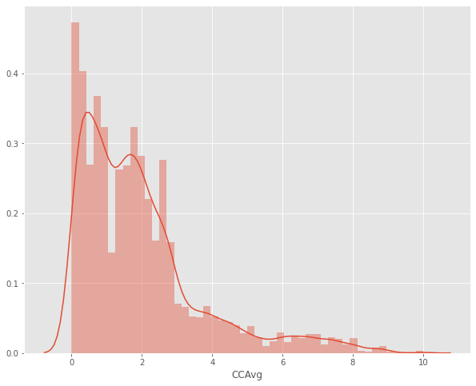

```python
# Example of a skewed distribution (right tail)

sns.distplot(pdata['CCAvg'])
plt.show()
```

```python
# Check whether any of the columns has any value other than numeric i.e. data is not corrupted such as a "?" instead of
# a number.

pdata[~pdata.applymap(np.isreal).all(1)]
```

|  | ID | Age | Experience | Income | ZIP Code | Family | CCAvg | Education | Mortgage | Personal Loan | Securities Account | CD Account | Online | CreditCard |
| --- | --- | --- | --- | --- | --- | --- | --- | --- | --- | --- | --- | --- | --- | --- |

# Inference

**If skewness value is zero than it is not skewed** **If it is less than zero then negatively skewed (left tail) and if greater than zero then positively skewed (right tail)**

**Data for most of the attributes (Age, Experience, Income, Family, CCAvg, Education, Mortgage, Personal Loan, Securities Account, CD Account, Online and Credit Card) seems to be skewed.

**Particularly CD Account, Securities Account, Personal Loan, Mortgage and CCAvg are highly skewed (right tail).

**Additionally Experience column contains negative values which can't be true and needs to be fixed

```python
pdata['Personal Loan'].value_counts()
# See distrubtion of target variable
```

```
0    4520
1     480
Name: Personal Loan, dtype: int64
```

```python
pdata['Personal Loan'].value_counts(normalize=True)*100
# See percentage distribution of target variable
```

```
0   90.40
1    9.60
Name: Personal Loan, dtype: float64
```

# BiVariate

```python
#  DataFrame for Bivariate analysis
tmp = pdata.copy()
columns = ['ID','ZIP Code'] # Drop ID, Zip Code columns for bivariate analysis
tmp.drop(columns, inplace = True,axis=1)
```

```python
# Look at the target column 'Personal Loan' to understand how the data is distributed amongst the various fields
tmp.groupby(["Personal Loan"]).mean()
```

| Personal Loan | Age | Experience | Income | Family | CCAvg | Education | Mortgage | Securities Account | CD Account | Online | CreditCard |
| --- | --- | --- | --- | --- | --- | --- | --- | --- | --- | --- | --- |
| 0 | 45.37 | 20.13 | 66.24 | 2.37 | 1.73 | 1.84 | 51.79 | 0.10 | 0.04 | 0.60 | 0.29 |
| 1 | 45.07 | 19.84 | 144.75 | 2.61 | 3.91 | 2.23 | 100.85 | 0.12 | 0.29 | 0.61 | 0.30 |

```python
# Look at the target column 'Personal Loan'  to understand how the data is distributed amongst the various fields
tmp.groupby(["Personal Loan"]).median()
```

| Personal Loan | Age | Experience | Income | Family | CCAvg | Education | Mortgage | Securities Account | CD Account | Online | CreditCard |
| --- | --- | --- | --- | --- | --- | --- | --- | --- | --- | --- | --- |
| 0 | 45.00 | 20.00 | 59.00 | 2.00 | 1.40 | 2.00 | 0.00 | 0.00 | 0.00 | 1.00 | 0.00 |
| 1 | 45.00 | 20.00 | 142.50 | 3.00 | 3.80 | 2.00 | 0.00 | 0.00 | 0.00 | 1.00 | 0.00 |

**Income, CC Average and Mortgage seems to be higher for folks who have availed Personal Loan** Income and CCAverage seems to be higher for folks who have availed Personal Loan

**Pairplot

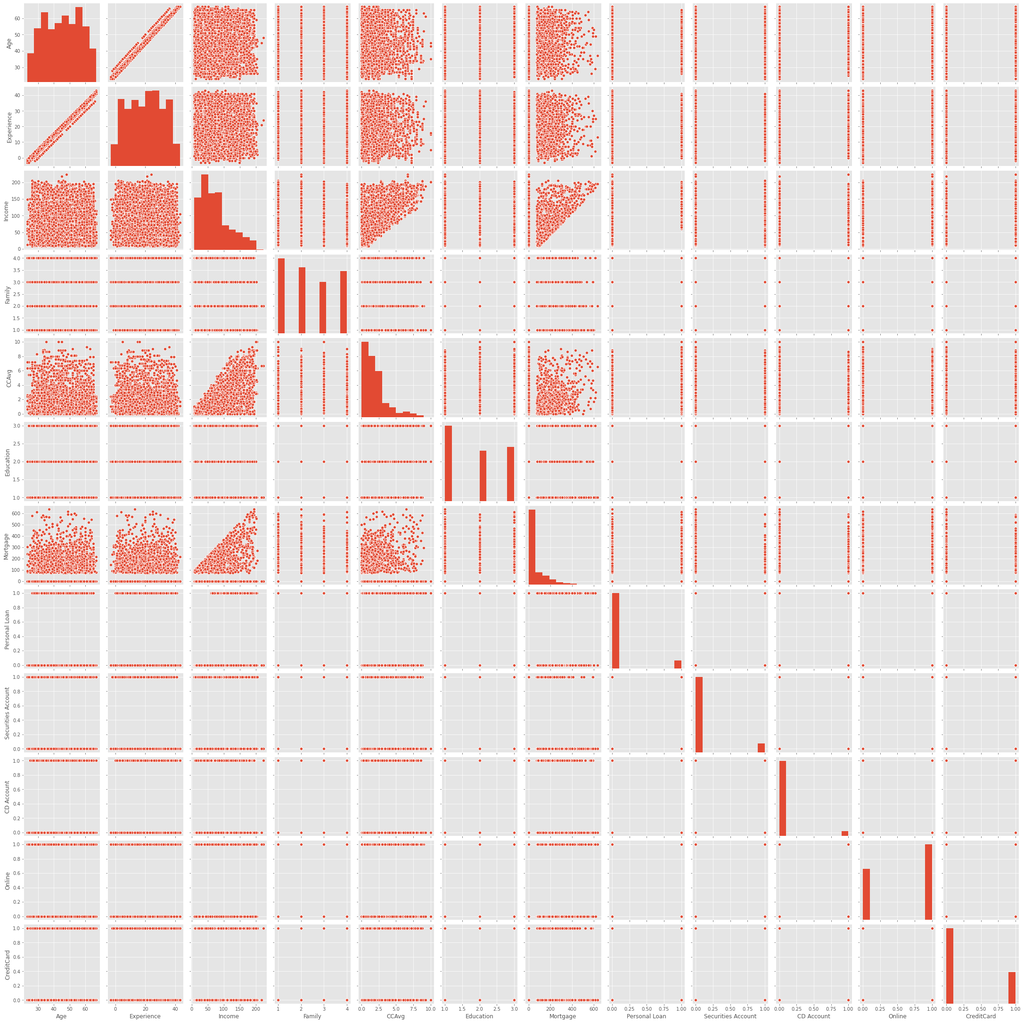

```python
#sns.pairplot(tmp, diag_kind='kde')
sns.pairplot(tmp)

plt.show()
```

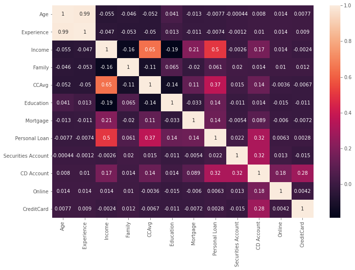

```python
#corr = tmp.drop('Personal Loan',axis=1).corr()
corr = tmp.corr()

plt.figure(figsize=(12,8))
sns.heatmap(corr, annot = True)
plt.show()
```

# Inference

**Personal Loan seems to have positive correlation with all columns except for Age and Experience.

**Personal Loan seems to have higher correleation with Income and Average

# Get Model Ready

```python
pdata.describe().T
## ID values are unique and hence needs to be dropped
## Experience seems to contain negative values which needs to be cleaned up
## Zip code contains values which are 4 digits. ZIP Code needs to be 5 digits. Need to replace all 4 digits values with max value
```

|  | count | mean | std | min | 25% | 50% | 75% | max |
| --- | --- | --- | --- | --- | --- | --- | --- | --- |
| ID | 5,000.00 | 2,500.50 | 1,443.52 | 1.00 | 1,250.75 | 2,500.50 | 3,750.25 | 5,000.00 |
| Age | 5,000.00 | 45.34 | 11.46 | 23.00 | 35.00 | 45.00 | 55.00 | 67.00 |
| Experience | 5,000.00 | 20.10 | 11.47 | -3.00 | 10.00 | 20.00 | 30.00 | 43.00 |
| Income | 5,000.00 | 73.77 | 46.03 | 8.00 | 39.00 | 64.00 | 98.00 | 224.00 |
| ZIP Code | 5,000.00 | 93,152.50 | 2,121.85 | 9,307.00 | 91,911.00 | 93,437.00 | 94,608.00 | 96,651.00 |
| Family | 5,000.00 | 2.40 | 1.15 | 1.00 | 1.00 | 2.00 | 3.00 | 4.00 |
| CCAvg | 5,000.00 | 1.94 | 1.75 | 0.00 | 0.70 | 1.50 | 2.50 | 10.00 |
| Education | 5,000.00 | 1.88 | 0.84 | 1.00 | 1.00 | 2.00 | 3.00 | 3.00 |
| Mortgage | 5,000.00 | 56.50 | 101.71 | 0.00 | 0.00 | 0.00 | 101.00 | 635.00 |
| Personal Loan | 5,000.00 | 0.10 | 0.29 | 0.00 | 0.00 | 0.00 | 0.00 | 1.00 |
| Securities Account | 5,000.00 | 0.10 | 0.31 | 0.00 | 0.00 | 0.00 | 0.00 | 1.00 |
| CD Account | 5,000.00 | 0.06 | 0.24 | 0.00 | 0.00 | 0.00 | 0.00 | 1.00 |
| Online | 5,000.00 | 0.60 | 0.49 | 0.00 | 0.00 | 1.00 | 1.00 | 1.00 |
| CreditCard | 5,000.00 | 0.29 | 0.46 | 0.00 | 0.00 | 0.00 | 1.00 | 1.00 |

```python
pdata.dtypes
# Family, Personal Loan, Securities Account, CD Account, , Online and Credit Card seems to integer type. We need to change it into categorical values
```

```
ID                      int64
Age                     int64
Experience              int64
Income                  int64
ZIP Code                int64
Family                  int64
CCAvg                 float64
Education               int64
Mortgage                int64
Personal Loan           int64
Securities Account      int64
CD Account              int64
Online                  int64
CreditCard              int64
dtype: object
```

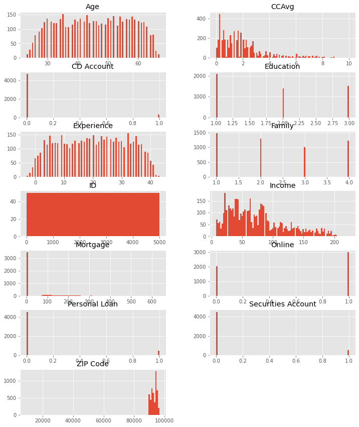

```python
columns = list(pdata)[:-1]
pdata[columns].hist(stacked=False, bins=100, figsize=(12,30), layout=(14,2));
# Histogram of first 13 columns
```

```python
#Drawing relationship between Personal Loan and Eduction
#
pdata.groupby(['Education'])['Personal Loan'].value_counts()
```

```
Education  Personal Loan
1          0                2003
           1                  93
2          0                1221
           1                 182
3          0                1296
           1                 205
Name: Personal Loan, dtype: int64
```

```python
# Create new dataframe to get model ready

df = pdata.copy() # Utilize df for performing all operations and get model ready
```

```python
df.drop('ID',axis=1,inplace=True)

## ID column: As all the values are unique in the column, it doen't help our model to predict anything
```

```python
df[df < 0] = 0

# Only Experience has negative values. So replacing it with 0
```

```python
## Zip code contains values which are 4 digits. ZIP Code needs to be 5 digits. Need to replace all 4 digits values with max value
str = df['ZIP Code'].max() # Utilizing max since mode here will return a zip code with decimals and that may not be accurate

for i in range(len(df)) :
    if df.loc[i, "ZIP Code"] < 10000:
        df.loc[i, "ZIP Code"] = str
```

```python
# Family, Education, Personal Loan, Securities Account, CD Account, , Online and Credit Card seems to integer type. We need to change it into categorical values
lst = ['Family','Education','Personal Loan','Securities Account','CD Account','Online','CreditCard']

# List all the categories for the columns which contains categorical values
for i in lst:   # checking value counts of all object type columns
    print(df[i].value_counts())
    print()
```

```
1    1472
2    1296
4    1222
3    1010
Name: Family, dtype: int64

1    2096
3    1501
2    1403
Name: Education, dtype: int64

0    4520
1     480
Name: Personal Loan, dtype: int64

0    4478
1     522
Name: Securities Account, dtype: int64

0    4698
1     302
Name: CD Account, dtype: int64

1    2984
0    2016
Name: Online, dtype: int64

0    3530
1    1470
Name: CreditCard, dtype: int64
```

```python
# Family, Personal Loan, Securities Account, CD Account, , Online and Credit Card seems to integer type. We need to change it into categorical values
lst = ['Family','Education','Personal Loan','Securities Account','CD Account','Online','CreditCard']

# Change all columns which contains categorical values into category type
for i in lst:   # checking value counts of all object type columns
    df[lst] = df[lst].astype('category')
```

```python
df.dtypes
```

```
Age                      int64
Experience               int64
Income                   int64
ZIP Code                 int64
Family                category
CCAvg                  float64
Education             category
Mortgage                 int64
Personal Loan         category
Securities Account    category
CD Account            category
Online                category
CreditCard            category
dtype: object
```

```python
df.info()
```

```
<class 'pandas.core.frame.DataFrame'>
RangeIndex: 5000 entries, 0 to 4999
Data columns (total 13 columns):
 #   Column              Non-Null Count  Dtype
---  ------              --------------  -----
 0   Age                 5000 non-null   int64
 1   Experience          5000 non-null   int64
 2   Income              5000 non-null   int64
 3   ZIP Code            5000 non-null   int64
 4   Family              5000 non-null   category
 5   CCAvg               5000 non-null   float64
 6   Education           5000 non-null   category
 7   Mortgage            5000 non-null   int64
 8   Personal Loan       5000 non-null   category
 9   Securities Account  5000 non-null   category
 10  CD Account          5000 non-null   category
 11  Online              5000 non-null   category
 12  CreditCard          5000 non-null   category
dtypes: category(7), float64(1), int64(5)
memory usage: 269.4 KB
```

```python
df.describe().T
```

|  | count | mean | std | min | 25% | 50% | 75% | max |
| --- | --- | --- | --- | --- | --- | --- | --- | --- |
| Age | 5,000.00 | 45.34 | 11.46 | 23.00 | 35.00 | 45.00 | 55.00 | 67.00 |
| Experience | 5,000.00 | 20.12 | 11.44 | 0.00 | 10.00 | 20.00 | 30.00 | 43.00 |
| Income | 5,000.00 | 73.77 | 46.03 | 8.00 | 39.00 | 64.00 | 98.00 | 224.00 |
| ZIP Code | 5,000.00 | 93,169.97 | 1,760.14 | 90,005.00 | 91,911.00 | 93,437.00 | 94,608.00 | 96,651.00 |
| CCAvg | 5,000.00 | 1.94 | 1.75 | 0.00 | 0.70 | 1.50 | 2.50 | 10.00 |
| Mortgage | 5,000.00 | 56.50 | 101.71 | 0.00 | 0.00 | 0.00 | 101.00 | 635.00 |

```python
df.head()
```

|  | Age | Experience | Income | ZIP Code | Family | CCAvg | Education | Mortgage | Personal Loan | Securities Account | CD Account | Online | CreditCard |
| --- | --- | --- | --- | --- | --- | --- | --- | --- | --- | --- | --- | --- | --- |
| 0 | 25 | 1 | 49 | 91107 | 4 | 1.60 | 1 | 0 | 0 | 1 | 0 | 0 | 0 |
| 1 | 45 | 19 | 34 | 90089 | 3 | 1.50 | 1 | 0 | 0 | 1 | 0 | 0 | 0 |
| 2 | 39 | 15 | 11 | 94720 | 1 | 1.00 | 1 | 0 | 0 | 0 | 0 | 0 | 0 |
| 3 | 35 | 9 | 100 | 94112 | 1 | 2.70 | 2 | 0 | 0 | 0 | 0 | 0 | 0 |
| 4 | 35 | 8 | 45 | 91330 | 4 | 1.00 | 2 | 0 | 0 | 0 | 0 | 0 | 1 |

```python
prop_Y = df['Personal Loan'].value_counts(normalize=True)
print(prop_Y)
```

```
0   0.90
1   0.10
Name: Personal Loan, dtype: float64
```

There is a slight imbalance in the target variable i.e., only 10% of total have applied for loan and this needs to be adjusted a bit.

# Question#3 - Split the data into training and test set in the ratio of 70:30 respectively (5 marks)

```python
# first lets build a simple model with all variables and as is
# we will have to convert the string variables to dummy variables
dummy_df = df

x=dummy_df.drop("Personal Loan",axis=1)
y=dummy_df["Personal Loan"]

#Convert categorical vriables to dummy variables
x = pd.get_dummies(x, drop_first=True)

#split the data into train and test
from sklearn.model_selection import train_test_split
x_train,x_test,y_train,y_test=train_test_split(x,y,test_size=0.3,random_state=1)
```

```python
print("{0:0.2f}% data is in training set".format((len(x_train)/len(pdata.index)) * 100))
print("{0:0.2f}% data is in test set".format((len(x_test)/len(pdata.index)) * 100))
```

```
70.00% data is in training set
30.00% data is in test set
```

```python
x_train.head()
```

|  | Age | Experience | Income | ZIP Code | CCAvg | Mortgage | Family_2 | Family_3 | Family_4 | Education_2 | Education_3 | Securities Account_1 | CD Account_1 | Online_1 | CreditCard_1 |
| --- | --- | --- | --- | --- | --- | --- | --- | --- | --- | --- | --- | --- | --- | --- | --- |
| 1334 | 47 | 22 | 35 | 94304 | 1.30 | 0 | 1 | 0 | 0 | 0 | 0 | 0 | 0 | 1 | 0 |
| 4768 | 38 | 14 | 39 | 93118 | 2.00 | 0 | 0 | 0 | 0 | 1 | 0 | 0 | 0 | 1 | 0 |
| 65 | 59 | 35 | 131 | 91360 | 3.80 | 0 | 0 | 0 | 0 | 0 | 0 | 0 | 0 | 1 | 1 |
| 177 | 29 | 3 | 65 | 94132 | 1.80 | 244 | 0 | 0 | 1 | 1 | 0 | 0 | 0 | 0 | 0 |
| 4489 | 39 | 13 | 21 | 95518 | 0.20 | 0 | 0 | 1 | 0 | 1 | 0 | 0 | 0 | 1 | 0 |

```python
#Build the logistic regression model
import statsmodels.api as sm

logit = sm.Logit(y_train, sm.add_constant(x_train))
lg = logit.fit()
```

```
Optimization terminated successfully.
         Current function value: 0.107508
         Iterations 10
```

```python
lg.summary()
```

Logit Regression Results

| Dep. Variable: | Personal Loan | No. Observations: | 3500 |
| --- | --- | --- | --- |
| Model: | Logit | Df Residuals: | 3484 |
| Method: | MLE | Df Model: | 15 |
| Date: | Tue, 07 Jul 2020 | Pseudo R-squ.: | 0.6565 |
| Time: | 13:28:10 | Log-Likelihood: | -376.28 |
| converged: | True | LL-Null: | -1095.5 |
| Covariance Type: | nonrobust | LLR p-value: | 9.210e-298 |

|  | coef | std err | z | P>\|z\| | [0.025 | 0.975] |
| --- | --- | --- | --- | --- | --- | --- |
| const | -12.8966 | 5.518 | -2.337 | 0.019 | -23.712 | -2.081 |
| Age | -0.0091 | 0.082 | -0.111 | 0.912 | -0.169 | 0.151 |
| Experience | 0.0143 | 0.082 | 0.175 | 0.861 | -0.146 | 0.174 |
| Income | 0.0627 | 0.004 | 16.306 | 0.000 | 0.055 | 0.070 |
| ZIP Code | -3.111e-06 | 5.53e-05 | -0.056 | 0.955 | -0.000 | 0.000 |
| CCAvg | 0.2468 | 0.058 | 4.237 | 0.000 | 0.133 | 0.361 |
| Mortgage | 0.0009 | 0.001 | 1.225 | 0.221 | -0.001 | 0.002 |
| Family_2 | 0.0314 | 0.291 | 0.108 | 0.914 | -0.540 | 0.602 |
| Family_3 | 2.4884 | 0.315 | 7.893 | 0.000 | 1.871 | 3.106 |
| Family_4 | 1.6423 | 0.310 | 5.290 | 0.000 | 1.034 | 2.251 |
| Education_2 | 4.0066 | 0.347 | 11.538 | 0.000 | 3.326 | 4.687 |
| Education_3 | 4.2732 | 0.347 | 12.302 | 0.000 | 3.592 | 4.954 |
| Securities Account_1 | -1.0702 | 0.405 | -2.640 | 0.008 | -1.865 | -0.276 |
| CD Account_1 | 3.7101 | 0.438 | 8.464 | 0.000 | 2.851 | 4.569 |
| Online_1 | -0.5861 | 0.206 | -2.843 | 0.004 | -0.990 | -0.182 |
| CreditCard_1 | -0.9985 | 0.270 | -3.703 | 0.000 | -1.527 | -0.470 |

Possibly complete quasi-separation: A fraction 0.14 of observations can be  
perfectly predicted. This might indicate that there is complete  
quasi-separation. In this case some parameters will not be identified.

```python
#Calculate Odds Ratio, probability
##create a data frame to collate Odds ratio, probability and p-value of the coef
lgcoef = pd.DataFrame(lg.params, columns=['coef'])
lgcoef.loc[:, "Odds_ratio"] = np.exp(lgcoef.coef)
lgcoef['probability'] = lgcoef['Odds_ratio']/(1+lgcoef['Odds_ratio'])
lgcoef['pval']=lg.pvalues
pd.options.display.float_format = '{:.2f}'.format
```

```python
lgcoef
```

|  | coef | Odds_ratio | probability | pval |
| --- | --- | --- | --- | --- |
| const | -12.90 | 0.00 | 0.00 | 0.02 |
| Age | -0.01 | 0.99 | 0.50 | 0.91 |
| Experience | 0.01 | 1.01 | 0.50 | 0.86 |
| Income | 0.06 | 1.06 | 0.52 | 0.00 |
| ZIP Code | -0.00 | 1.00 | 0.50 | 0.96 |
| CCAvg | 0.25 | 1.28 | 0.56 | 0.00 |
| Mortgage | 0.00 | 1.00 | 0.50 | 0.22 |
| Family_2 | 0.03 | 1.03 | 0.51 | 0.91 |
| Family_3 | 2.49 | 12.04 | 0.92 | 0.00 |
| Family_4 | 1.64 | 5.17 | 0.84 | 0.00 |
| Education_2 | 4.01 | 54.96 | 0.98 | 0.00 |
| Education_3 | 4.27 | 71.75 | 0.99 | 0.00 |
| Securities Account_1 | -1.07 | 0.34 | 0.26 | 0.01 |
| CD Account_1 | 3.71 | 40.86 | 0.98 | 0.00 |
| Online_1 | -0.59 | 0.56 | 0.36 | 0.00 |
| CreditCard_1 | -1.00 | 0.37 | 0.27 | 0.00 |

```python
# FIlter by significant p-value (pval <0.1) and sort descending by Odds ratio
lgcoef = lgcoef.sort_values(by="Odds_ratio", ascending=False)
pval_filter = lgcoef['pval']<=0.1
lgcoef[pval_filter]
```

|  | coef | Odds_ratio | probability | pval |
| --- | --- | --- | --- | --- |
| Education_3 | 4.27 | 71.75 | 0.99 | 0.00 |
| Education_2 | 4.01 | 54.96 | 0.98 | 0.00 |
| CD Account_1 | 3.71 | 40.86 | 0.98 | 0.00 |
| Family_3 | 2.49 | 12.04 | 0.92 | 0.00 |
| Family_4 | 1.64 | 5.17 | 0.84 | 0.00 |
| CCAvg | 0.25 | 1.28 | 0.56 | 0.00 |
| Income | 0.06 | 1.06 | 0.52 | 0.00 |
| Online_1 | -0.59 | 0.56 | 0.36 | 0.00 |
| CreditCard_1 | -1.00 | 0.37 | 0.27 | 0.00 |
| Securities Account_1 | -1.07 | 0.34 | 0.26 | 0.01 |
| const | -12.90 | 0.00 | 0.00 | 0.02 |

The p val of Age, Experience, Zip Code and Family_2 seems too high. In future after discussion with Bank on significance value this could be considered to be removed for improvement of models.

# Question#4 - Use Logistic Regression model to predict the number of a customers buying personal loans. Print all the metrics related for evaluating the model performance (15 marks)

```python
from sklearn.metrics import confusion_matrix, recall_score, precision_score, f1_score, roc_auc_score,accuracy_score,classification_report
from sklearn.linear_model import LogisticRegression

# Fit the model on train
model = LogisticRegression(solver="liblinear", random_state=42)

model.fit(x_train, y_train)
#predict on test
y_predict = model.predict(x_test)


coef_df = pd.DataFrame(model.coef_)
coef_df['intercept'] = model.intercept_
print(coef_df)
```

```
     0     1    2     3    4    5     6    7    8    9   10   11   12    13  \
0 0.00 -0.00 0.04 -0.00 0.02 0.00 -0.01 0.01 0.01 0.01 0.01 0.00 0.01 -0.00

     14  intercept
0 -0.00      -0.00
```

```python
#model_score = model.score(x_test, y_test)
#print(model_score)
```

```python
## function to get confusion matrix in a proper format
def draw_cm( actual, predicted ):
    cm = confusion_matrix( actual, predicted)
    sns.heatmap(cm, annot=True,  fmt='.2f', xticklabels = [0,1] , yticklabels = [0,1] )
    plt.ylabel('Observed')
    plt.xlabel('Predicted')
    plt.show()
```

```
Training accuracy 0.91

Testing accuracy 0.907

Confusion Matrix
```

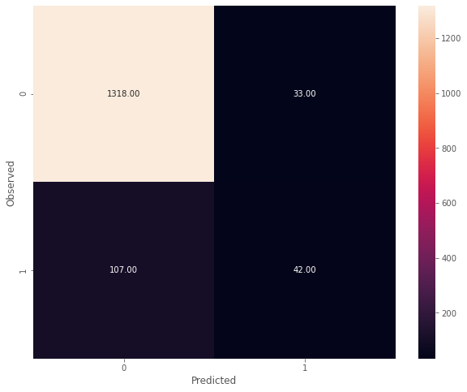

```
None

              precision    recall  f1-score   support

     class 0       0.92      0.98      0.95      1351
     class 1       0.56      0.28      0.37       149

    accuracy                           0.91      1500
   macro avg       0.74      0.63      0.66      1500
weighted avg       0.89      0.91      0.89      1500


Roc Auc Score: 0.6287264218898255
```

```python
print("Training accuracy",round(model.score(x_train,y_train),3))
print()
print("Testing accuracy",round(model.score(x_test, y_test),3))
print()
print('Confusion Matrix')
print(draw_cm(y_test,y_predict))
print()
targetnames = ['class 0','class 1']
print(classification_report(y_test, y_predict,target_names=targetnames))
print()
print("Roc Auc Score:",roc_auc_score(y_test,y_predict))
```

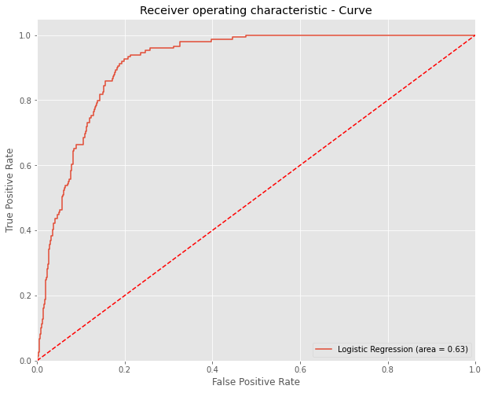

```python
#AUC ROC curve
from sklearn.metrics import roc_auc_score
from sklearn.metrics import roc_curve

logit_roc_auc = roc_auc_score(y_test, model.predict(x_test))
fpr, tpr, thresholds = roc_curve(y_test, model.predict_proba(x_test)[:,1])
plt.figure()
plt.plot(fpr, tpr, label='Logistic Regression (area = %0.2f)' % logit_roc_auc)
plt.plot([0, 1], [0, 1],'r--')
plt.xlim([0.0, 1.0])
plt.ylim([0.0, 1.05])
plt.xlabel('False Positive Rate')
plt.ylabel('True Positive Rate')
plt.title('Receiver operating characteristic - Curve')
plt.legend(loc="lower right")
plt.savefig('Log_ROC')
plt.show()
```

# Question#5 - Give your reasoning on how can the model perform better? (10 marks) Hint: Check parameter

# The two metrics for evaluating our model in this situation are: 1. Recall or sensitivity 2. ROC Curve We need to improve both of them to effectively predict the more liability customers who can be converted to personal loan customers in this situation. Also, the training score is higher than the testing score. This needs to be corrected by adjusting the various parameters.

```python
# Running a loop to check different values of 'solver'

train_score=[]
test_score=[]
solver = ['newton-cg','lbfgs','liblinear','sag','saga']
for i in solver:
    model = LogisticRegression(random_state=42,penalty='l2', C = 0.75,solver=i)  # changing values of solver
    model.fit(x_train, y_train)
    y_predict = model.predict(x_test)
    train_score.append(round(model.score(x_train, y_train),3))
    test_score.append(round(model.score(x_test, y_test),3))

print(solver)
print()
print(train_score)
print()
print(test_score)
```

```
['newton-cg', 'lbfgs', 'liblinear', 'sag', 'saga']

[0.959, 0.909, 0.91, 0.905, 0.905]

[0.953, 0.908, 0.907, 0.901, 0.901]
```

```python
train_score=[]
test_score=[]
solver = ['liblinear','saga']   # changing values of solver which works with 'l1'
for i in solver:
    model = LogisticRegression(random_state=42,penalty='l1', C = 0.75,solver=i)  #changed penalty to 'l1'
    model.fit(x_train, y_train)
    y_predict = model.predict(x_test)
    train_score.append(round(model.score(x_train, y_train),3))
    test_score.append(round(model.score(x_test, y_test),3))

print(solver)
print()
print(train_score)
print()
print(test_score)
```

```
['liblinear', 'saga']

[0.962, 0.905]

[0.957, 0.901]
```

```python
model = LogisticRegression(random_state=42,penalty='l1',solver='liblinear',class_weight='balanced') # changing class weight to balanced

model.fit(x_train, y_train)

y_predict = model.predict(x_test)

print("Training accuracy",model.score(x_train,y_train))
print()
print("Testing accuracy",model.score(x_test, y_test))
```

```
Training accuracy 0.9142857142857143

Testing accuracy 0.906
```

```python
# Running a loop to check different values of 'C'

train_score=[]
test_score=[]
C = [0.01,0.1,0.25,0.5,0.75,1]
for i in C:
    #model = LogisticRegression(random_state=42,penalty='l1', solver='liblinear',class_weight='balanced', C=i)  # changing values of C
    model = LogisticRegression(random_state=42,penalty='l1', solver='liblinear', C=i)  # changing values of C
    model.fit(x_train, y_train)
    y_predict = model.predict(x_test)
    train_score.append(round(model.score(x_train,y_train),3)) # appending training accuracy in a blank list for every run of the loop
    test_score.append(round(model.score(x_test, y_test),3))   # appending testing accuracy in a blank list for every run of the loop

print(C)
print()
print(train_score)
print()
print(test_score)
```

```
[0.01, 0.1, 0.25, 0.5, 0.75, 1]

[0.908, 0.955, 0.96, 0.961, 0.962, 0.962]

[0.909, 0.949, 0.953, 0.957, 0.957, 0.957]
```

```
Training accuracy 0.912

Testing accuracy 0.914

Confusion Matrix
```

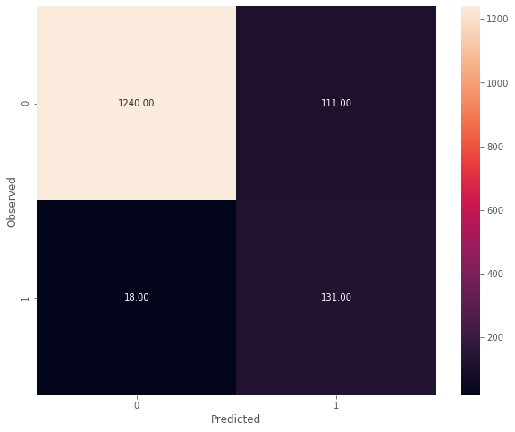

```
None

              precision    recall  f1-score   support

     class 0       0.99      0.92      0.95      1351
     class 1       0.54      0.88      0.67       149

    accuracy                           0.91      1500
   macro avg       0.76      0.90      0.81      1500
weighted avg       0.94      0.91      0.92      1500


Roc Auc Score: 0.8985166344591875
```

```python
#Therefore final model is
model = LogisticRegression(random_state=42,penalty='l1', solver='liblinear',C=0.08,class_weight='balanced')

model.fit(x_train, y_train)
y_predict = model.predict(x_test)
print("Training accuracy",round(model.score(x_train,y_train),3))
print()
print("Testing accuracy",round(model.score(x_test, y_test),3))
print()
print('Confusion Matrix')
print(draw_cm(y_test,y_predict))
print()
targetnames = ['class 0','class 1']
print(classification_report(y_test, y_predict,target_names=targetnames))
print()
print("Roc Auc Score:",roc_auc_score(y_test,y_predict))
```

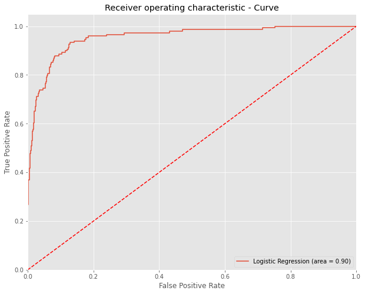

```python
#AUC ROC curve
from sklearn.metrics import roc_auc_score
from sklearn.metrics import roc_curve

logit_roc_auc = roc_auc_score(y_test, model.predict(x_test))
fpr, tpr, thresholds = roc_curve(y_test, model.predict_proba(x_test)[:,1])
plt.figure()
plt.plot(fpr, tpr, label='Logistic Regression (area = %0.2f)' % logit_roc_auc)
plt.plot([0, 1], [0, 1],'r--')
plt.xlim([0.0, 1.0])
plt.ylim([0.0, 1.05])
plt.xlabel('False Positive Rate')
plt.ylabel('True Positive Rate')
plt.title('Receiver operating characteristic - Curve')
plt.legend(loc="lower right")
plt.savefig('Log_ROC_final')
plt.show()
```

# Question#6 - Give Business understanding of your model? (5 marks)

# Confusion matrix means True Positive (observed=1,predicted=1): Predicted that customer will apply for loan and the customer applied False Positive (observed=0,predicted=1): Predicted that customer will apply for loan and the customer didn't apply True Negative (observed=0,predicted=0): Predicted that customer will not apply for loan and the customer didn't apply for loan False Negative (observed=1,predicted=0): Predicted that customer will not apply for loan and the customer applied Here the bank wants to give personal loans to the people who are eligible i.e. more TP and less FN so that the bank doesn't lose customers. Hence Recall or Sensitivity is the important metric. In case of False positive bank i.e., predicted that customer will apply for loan and the customer didn't apply can be higher since the bussiness goal is to convert more liability customers into personal loan customers. After achieving the desired accuracy we can deploy the model for practical use. As in the bank now can predict who is eligible for home loan. They can use the model for upcoming customers.